# Python lab 12

## Time Series Analysis

Please import the student engagement data `engagement_data.xlsx`. In this dataset we know students' page visits on different days and times. Students are labeled by their achievement levels.

```python
df = pd.read_excel('engagement-data.xlsx', index_col=0, parse_dates=True)
df.head(5)
```

| timestamp | student_id | page | achievement_level |
| --- | --- | --- | --- |
| 2023-12-29 02:32:23 | 0 | Page4 | Low Achiever |
| 2023-12-29 04:18:23 | 0 | Page4 | Low Achiever |
| 2023-12-28 16:15:23 | 0 | Page4 | Low Achiever |
| 2023-09-09 23:50:11 | 0 | Page2 | Low Achiever |
| 2023-09-10 00:18:11 | 0 | Page2 | Low Achiever |

Our data contains students visits on specific hours of each day. To start with we should compute students' daily page visit counts (i.e., how many pages a student visited per each day in the dataset).

To achieve, we should first apply `groupby` with `student_id` and `achievement_level`. Grouping by `student_id` is necessary because we want to compute total interactions per student. `achievement_level` is also included in the grouping just to carry over this information as index value. If not, `achievement_level` column would be lost totally. We will need it later

On the grouped data you should apply `resample` by day (`D`) and then the the `size` function to count the number of interactions.

The final outcome should be stored in `daily_interactions`, which should look like the following:

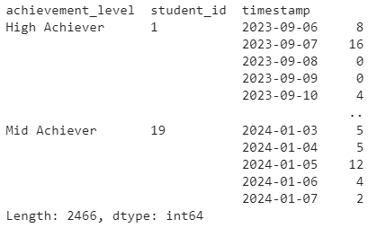

```python
daily_interactions = df.groupby(['achievement_level', 'student_id']).resample('D').size()
daily_interactions
```

```
achievement_level  student_id  timestamp
High Achiever      1           2023-09-06     8
                               2023-09-07    16
                               2023-09-08     0
                               2023-09-09     0
                               2023-09-10     4
                                             ..
Mid Achiever       19          2024-01-03     5
                               2024-01-04     5
                               2024-01-05    12
                               2024-01-06     4
                               2024-01-07     2
Length: 2466, dtype: int64
```

We are interested in knowing students' average page visits for a period of 7 days throughout the semester. We will apply a moving average (i.e., `rolling`) and store the result in `rolling_mean`.

`rolling_mean` will be a Series. You should apply `to_frame(name='avg_engagement')` to convert it into a dataframe.

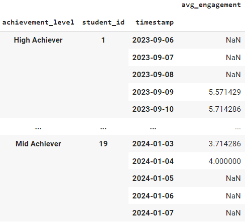

```python
rolling_mean = daily_interactions.rolling(window=7, center=True).mean()
rolling_mean = rolling_mean.to_frame(name='avg_engagement')
rolling_mean
```

| achievement_level | student_id | timestamp | avg_engagement |
| --- | --- | --- | --- |
| High Achiever | 1 | 2023-09-06 | NaN |
|  |  | 2023-09-07 | NaN |
|  |  | 2023-09-08 | NaN |
|  |  | 2023-09-09 | 5.571429 |
|  |  | 2023-09-10 | 5.714286 |
| ... | ... | ... | ... |
| Mid Achiever | 19 | 2024-01-03 | 3.714286 |
|  |  | 2024-01-04 | 4.000000 |
|  |  | 2024-01-05 | NaN |
|  |  | 2024-01-06 | NaN |
|  |  | 2024-01-07 | NaN |

2466 rows × 1 columns

Now, our data is ready. Please execute the following code to visualize the `rolling_mean`. This visualization will display all students' daily interaction with 7-day rolling mean:

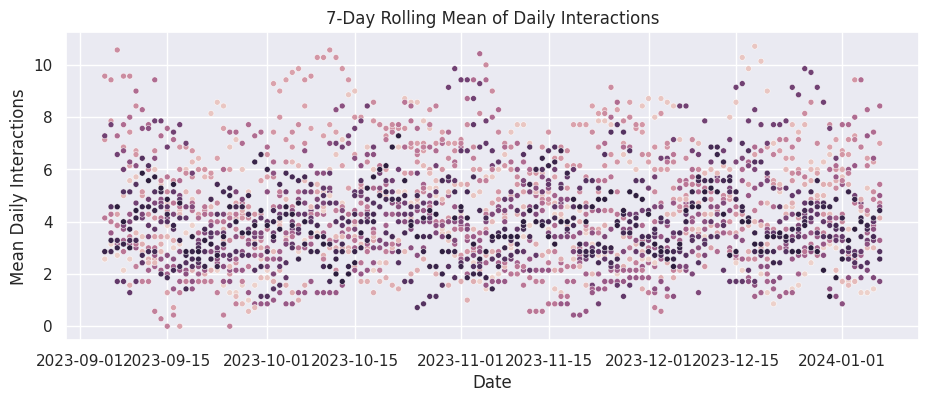

```python
sns.scatterplot(data=rolling_mean, x='timestamp', y='avg_engagement', hue='student_id', legend=False, size = 1)
plt.title('7-Day Rolling Mean of Daily Interactions')
plt.ylabel('Mean Daily Interactions')
plt.xlabel('Date')

plt.show()
```

I think it looks very messy since we have all students' data at once. Since we set `hue='student_id'`, different colors were assigned to each student. Although this helps us differentiate between students, it is still almost impossible to make sense of it.

One option could be to color students by their achievement levels. So, let's change the visualization by setting `hue` to `achievement_level`. `hue` helps us to group data by assigning a varying colors to each group:

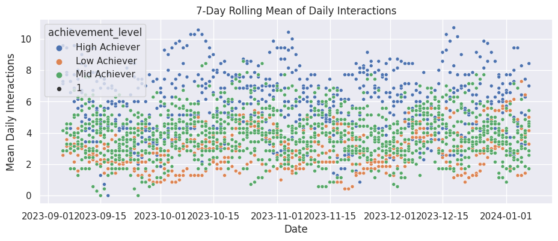

```python
sns.scatterplot(data=rolling_mean, x='timestamp', y='avg_engagement',
                hue='achievement_level', legend=True, size = 1)
plt.title('7-Day Rolling Mean of Daily Interactions')
plt.ylabel('Mean Daily Interactions')
plt.xlabel('Date')

plt.show()
```

Now, the visualization is a bit more interpretable. High achievers (blue points) are mostly located at the top section and therefore they engaged quite with the tutorial pages. Mid achievers (green points) are mostly located just below them. The low achievers (orange dots) are usually at the bottom part.

But, since we still have a mean score for each student, the graph is still not very clear.

What if we create a mean score per each achievement group? With this approach, we could obtain a simpler graph like this:

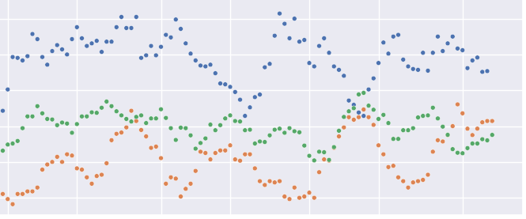

To start with tihs task, in the below cell, you should group `rolling_mean` by `'achievement_level', 'timestamp'`. We do this because we are interested in each achievement groups' average engagement not each students' specific engagement.

After groupby, you should select `avg_engagement` column and compute `mean`. So, basically we are computing the average engagement of each achievement level at teach timestamp.

Store the final result to `rolling_mean2` and print it. Your output should match the following:

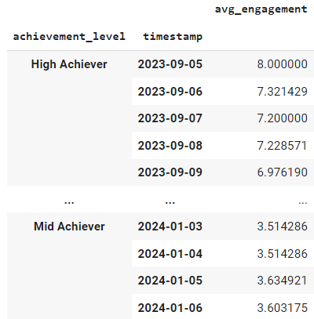

```python
rolling_mean2 = rolling_mean.groupby(['achievement_level', 'timestamp'])['avg_engagement'].mean()
rolling_mean2 = rolling_mean2.to_frame(name='avg_engagement')
rolling_mean2
```

| achievement_level | timestamp | avg_engagement |
| --- | --- | --- |
| High Achiever | 2023-09-05 | 8.000000 |
|  | 2023-09-06 | 7.321429 |
|  | 2023-09-07 | 7.200000 |
|  | 2023-09-08 | 7.228571 |
|  | 2023-09-09 | 6.976190 |
| ... | ... | ... |
| Mid Achiever | 2024-01-03 | 3.514286 |
|  | 2024-01-04 | 3.514286 |
|  | 2024-01-05 | 3.634921 |
|  | 2024-01-06 | 3.603175 |
|  | 2024-01-07 | 3.755102 |

375 rows × 1 columns

Now, execute the following code to obtain the final visualization:

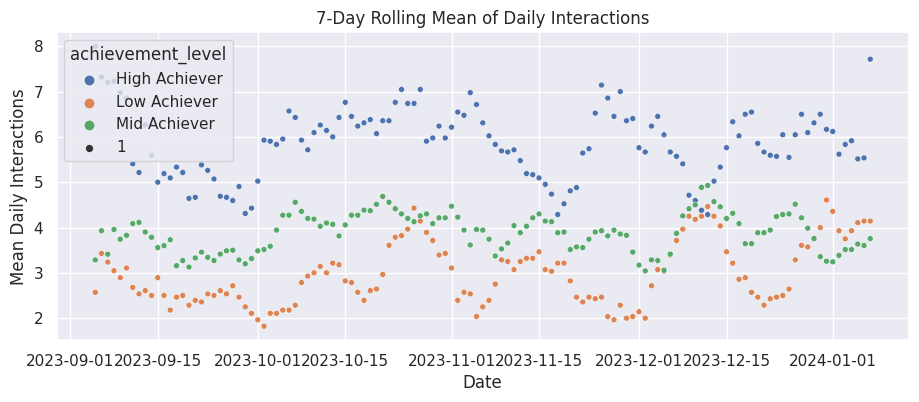

```python
sns.scatterplot(data=rolling_mean2, x='timestamp', y='avg_engagement', hue='achievement_level', legend=True, size = 1)
plt.title('7-Day Rolling Mean of Daily Interactions')
plt.ylabel('Mean Daily Interactions')
plt.xlabel('Date')

plt.show()
```

**Computing Weekly Means (without Rolling Window)**

Below, step by step all codes are writen to compute and visualize the weekly averages across different achievement levels. This time, no rolling window is used, to compare the final visualizations. Please go through the code and check the latest visualization.

```python
df.head(2)
```

| timestamp | student_id | page | achievement_level |
| --- | --- | --- | --- |
| 2023-12-29 02:32:23 | 0 | Page4 | Low Achiever |
| 2023-12-29 04:18:23 | 0 | Page4 | Low Achiever |

```python
#computing the daily interactions by each engagement group
dailyByAchievement = df.groupby(['achievement_level']).resample('D').size()
dailyByAchievement.head(3)
```

| timestamp achievement_level | 2023-09-05 | 2023-09-06 | 2023-09-07 | 2023-09-08 | 2023-09-09 | 2023-09-10 | 2023-09-11 | 2023-09-12 | 2023-09-13 | 2023-09-14 | ... | 2023-12-29 | 2023-12-30 | 2023-12-31 | 2024-01-01 | 2024-01-02 | 2024-01-03 | 2024-01-04 | 2024-01-05 | 2024-01-06 | 2024-01-07 |
| --- | --- | --- | --- | --- | --- | --- | --- | --- | --- | --- | --- | --- | --- | --- | --- | --- | --- | --- | --- | --- | --- |
| High Achiever | 15 | 33 | 86 | 42 | 24 | 42 | 36 | 26 | 32 | 25 | ... | 50 | 44 | 23 | 46 | 38 | 30 | 21 | 19 | 30 | 14 |
| Low Achiever | 3 | 13 | 12 | 5 | 10 | 14 | 6 | 17 | 19 | 0 | ... | 27 | 18 | 9 | 14 | 16 | 27 | 11 | 15 | 13 | 13 |
| Mid Achiever | 11 | 17 | 41 | 29 | 48 | 35 | 45 | 29 | 32 | 68 | ... | 40 | 30 | 26 | 25 | 41 | 36 | 29 | 50 | 39 | 19 |

3 rows × 125 columns

```python
dailyByAchievement = dailyByAchievement.stack()
dailyByAchievement
```

```
achievement_level  timestamp
High Achiever      2023-09-05    15
                   2023-09-06    33
                   2023-09-07    86
                   2023-09-08    42
                   2023-09-09    24
                                 ..
Mid Achiever       2024-01-03    36
                   2024-01-04    29
                   2024-01-05    50
                   2024-01-06    39
                   2024-01-07    19
Length: 375, dtype: int64
```

```python
#transforming the series object into a dataframe.
dailyByAchievement = dailyByAchievement.to_frame(name='avg_engagement')
dailyByAchievement.head(2)
```

| achievement_level | timestamp | avg_engagement |
| --- | --- | --- |
| High Achiever | 2023-09-05 | 15 |
|  | 2023-09-06 | 33 |

```python
#making the timestamp the only index of the dataframe.
#this is necessary for resampling in the next cell.
dailyByAchievement = dailyByAchievement.reset_index(level="achievement_level")
```

```python
#computing the weekly averages using `resample`
dailyByAchievement = dailyByAchievement.groupby('achievement_level').resample("W").mean(numeric_only=True)
dailyByAchievement.head(2)
```

| achievement_level | timestamp | avg_engagement |
| --- | --- | --- |
| High Achiever | 2023-09-10 | 40.333333 |
|  | 2023-09-17 | 33.571429 |

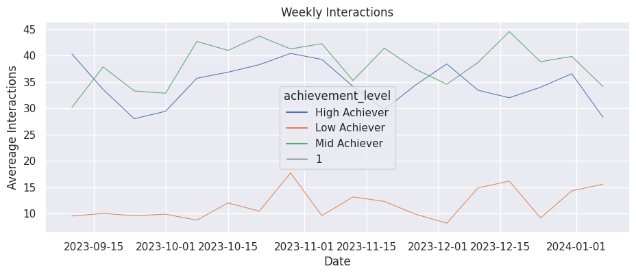

```python
#visualizing the data
sns.lineplot(data=dailyByAchievement, x='timestamp', y='avg_engagement', hue='achievement_level', legend=True, size = 1, markers="*")
plt.title('Weekly Interactions')
plt.ylabel('Avereage Interactions')
plt.xlabel('Date')

plt.show()
```

**Inconsistent Results**

If you pay attention to this visual, it is quite different than the previous one with rolling window. Below is the two figures are provided next to each other for your convenience.

Why do you think we obtained inconsistent results? Is there a problem with the codes somewhere?

Whoever first identifies the underlying issue by the end of the day will earn something :)

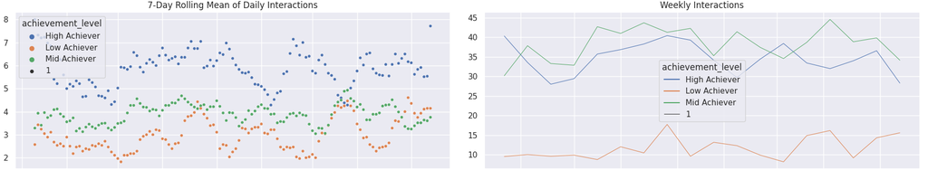